```python
%matplotlib inline
import numpy as np
import pandas as pd
import datetime as dt

from sklearn.decomposition import PCA
import statsmodels.api as sm
import statsmodels.tsa.stattools as st
import statsmodels.tsa as tsa
import matplotlib.pyplot as plt

import plotly
from plotly.offline import download_plotlyjs, init_notebook_mode, plot, iplot
import plotly.graph_objs as go

plotly.offline.init_notebook_mode()
```

# Nowcasting Brazilian Inflation Rate

# IPCA Data

First we need to manipulate IPCA Data in order to upload it to `Google Correlate` Tool.

We will switch the 2016.01 month from [ipea data](http://www.ipeadata.gov.br) to the 2016-01-01 date.

```python
inflation = pd.read_csv('ipca.csv', sep=';')
inflation.columns = ['Date', 'Ipca', 'Nothing']
inflation.drop('Nothing',inplace=True, axis=1)
inflation.head()
```

|  | Date | Ipca |
| --- | --- | --- |
| 0 | 1980.01 | 6,61564916057387 |
| 1 | 1980.02 | 4,61691885303424 |
| 2 | 1980.03 | 6,03838866463464 |
| 3 | 1980.04 | 5,28611382402557 |
| 4 | 1980.05 | 5,70272065101669 |

```python
def ipeaToDate(ipeaDate):
    return dt.datetime(int(ipeaDate.split('.')[0]),int(ipeaDate.split('.')[1]),1)
```

```python
def convertComma(numberString):
    return numberString.replace(',', '.')
```

```python
def convertStr(numberString):
    return ("%.2f" % numberString)
```

```python
inflation['Date'] = inflation['Date'].apply(convertStr)
inflation['Date'] = inflation['Date'].apply(ipeaToDate)
inflation.set_index('Date',inplace=True)

inflation = inflation.loc["2004-01-01":]

inflation.head()
```

| Date | Ipca |
| --- | --- |
| 2004-01-01 | 0,76 |
| 2004-02-01 | 0,61 |
| 2004-03-01 | 0,47 |
| 2004-04-01 | 0,37 |
| 2004-05-01 | 0,51 |

```python
inflation['Ipca'] = inflation['Ipca'].apply(convertComma)
inflation['Ipca'] = pd.to_numeric(inflation['Ipca'])
inflation = inflation / 100
inflation = inflation.loc[:"2016-01-01"]
inflation.tail()
```

| Date | Ipca |
| --- | --- |
| 2015-09-01 | 0.0054 |
| 2015-10-01 | 0.0082 |
| 2015-11-01 | 0.0101 |
| 2015-12-01 | 0.0096 |
| 2016-01-01 | 0.0127 |

```python
inflation.to_csv('exportedIpca.csv', header = False)
```

# IPCA Series Analysis

We will only look ate data posterior to 2003, since that's the available data range in both `Google Correlate`and `Google Trends`. First thing that comes tmind is that there seems to be some sort of seasonality. And the series might be approximately stationary.

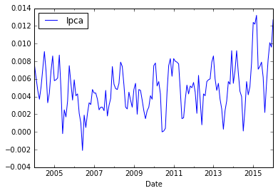

```python
inflation.loc["2004-01-01":].plot()
```

# Ipca Correlate Data

Uploading our IPCA series to [Google Correlate](https://www.google.com/trends/correlate/search?e=id%3ANhss-CMLXKj&t=monthly&p=br#default,30) we retrieved the following series.

```python
correlateIpca = pd.read_csv('correlateIpca.csv', comment='#')
correlateIpca.columns
```

```
Index(['Date', 'IPCA', 'cortar grama', 'umbu', 'como matar larvas',
       'compressor ar', 'cortador grama gasolina', 'roçadeira',
       'veneno para tiririca', 'cortador de grama', 'pernilongo', 'rocadeira',
       'acabar com moscas', 'como espantar moscas', 'como acabar com moscas',
       'formigas pequenas', 'acabar com as moscas', 'espantar moscas',
       'maquina de cortar grama a gasolina', 'suor excessivo na cabeça',
       'maritaca', 'como acabar com as moscas', 'aparador de grama'],
      dtype='object')
```

We might speculate some kind of interpretation that could explain how there variables correlate to inflation. Yet, they all look spurious.

To try to get more tangible results we will try to look for negative correlations, uploading the negative of the IPCA series.

```python
negativeInflation = -inflation
negativeInflation.to_csv('exportedIpcaNegative.csv', header = False)
```

Oddly enough, no data was found for our negative ipca series. Remember that Google Correlate's filtering mechanism only allows for series with 0.6 or more correlation.

# Level Analysis

Since the IPCA data rather refers to a rate of change, we speculate that there might be more interesting data correlated to the level of prices. In an attempt to retrieve more meaningful data we will build a price index starting at 1 and subject to IPCA changes.

```python
inflation.head()
```

| Date | Ipca |
| --- | --- |
| 2004-01-01 | 0.0076 |
| 2004-02-01 | 0.0061 |
| 2004-03-01 | 0.0047 |
| 2004-04-01 | 0.0037 |
| 2004-05-01 | 0.0051 |

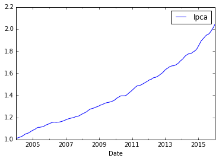

```python
pricesIndex = inflation + 1
pricesIndex = pricesIndex.cumprod()
pricesIndex.plot()
```

```python
pricesIndex.to_csv('exportedPriceLevel.csv', header = False)
```

The results are much more numerous. Using [Google Correlate](https://www.google.com/trends/correlate/search?e=id:Qwn4YYYbK2j&t=monthly&p=br#default,60) we found much more results:

```python
correlatePriceLevel = pd.read_csv('correlatePriceLevel.csv', comment='#')
correlatePriceLevel['Date'] = pd.to_datetime(correlatePriceLevel['Date'])
correlatePriceLevel.set_index('Date',inplace=True)

print('Number of matches: {number!s}'.format(number=len(list(correlatePriceLevel))))
for series in correlatePriceLevel.columns:
    print(series)
```

```
Number of matches: 101
PriceLevel
sensação de
trok
posso dar
quanto tempo
pode colocar
37 semanas
com quanto
5 meses
semanas
sonhar com a
a conta
morena linda
por quanto tempo
sangrar
tomar remedio
posso passar
quando o
ver preço
o anticoncepcional
coçando
e nao
7 meses
por quanto
bom para
quanto tempo tem
quantos dias
parecendo
que so
inflama
sinto dor
so pode
quantos ml
com quanto tempo
te abençoe
em cima do
nao veio
grudar
toragesic
```

[output cut: 47 more lines]

```
numero do cartao
banco sicoob
com quantas semanas
que remedio
transferir
o que tomar
receita com
com quantos meses
tomar o anticoncepcional
38 semanas
pode
o bebe
esta bem
sonhar com aranha
colher de sopa
```

We will choose the following series as non spurious:

```python
listOfSeries = [
    'com quanto',
    'por quanto tempo',
    'tomar remedio',
    'ver preço',
    'por quanto',
    'um kilo',
    'o que é bom',
    'de quanto',
    'da valor',
    'numero do cartao',
    'banco sicoob',
    'transferir',
]
```

Again, we will also look for negative correlations.

```python
pricesIndexNegative = - pricesIndex
pricesIndexNegative.to_csv('exportedPriceLevelNegative.csv', header = False)
```

```python
correlatePriceLevelNegative = pd.read_csv('correlatePriceLevelNegative.csv', comment='#')
correlatePriceLevelNegative['Date'] = pd.to_datetime(correlatePriceLevelNegative['Date'])
correlatePriceLevelNegative.set_index('Date',inplace=True)

print('Number of matches: {number!s}'.format(number=len(list(correlatePriceLevelNegative))))
for series in correlatePriceLevelNegative.columns:
    print(series)
```

```
Number of matches: 101
PriceLevelNegative
arquivos
instalando
info
programa de
letra musicas
letras das
de humor
de web
revista
.iso
alterando
digerati
xp
ecs
problemas com
em rede
media player
letras e
line
inserindo
fireworks
keygen
contrução
serial
fots
windows xp
editora abril
surforeggae
espaço rap
.dat
media
tutorial after
player
guia
lexmark
site musicas
tutorial photoshop
configurando
```

[output cut: 47 more lines]

```
xp professional
macoratti
teh
tribunal de justiça
quiroga
o linux
todeschini
driver para
jogo de damas
usb camera
tux
rhesus
redirecionar
site da igreja
testes de
```

```python
listOfSeries2 = [
    'revista',
    'xp',
    'contrução',
    'editora abril',
    'site revista',
    'menus',
    'moteis',
    'hotel in',
    'tribunal de justiça do',
    'sites de lojas',
    'revista quatro rodas',
    'andima',
    'justiça do',
    'tribunal de justiça',
    'alonegocios',
    'todeschini',
    'rhesus',
    'site da igreja',

]
```

# Level Model

On a first attempt to model the prices level we will use the above mentioned variables

```python
positiveCorr = correlatePriceLevel[listOfSeries]
positiveCorr.head()
```

| Date | com quanto | por quanto tempo | tomar remedio | ver preço | por quanto | um kilo | o que é bom | de quanto | da valor | numero do cartao | banco sicoob | transferir |
| --- | --- | --- | --- | --- | --- | --- | --- | --- | --- | --- | --- | --- |
| 2004-01-01 | -1.171 | -1.350 | -1.158 | -1.203 | -1.347 | -1.304 | -1.155 | -1.250 | -1.175 | -1.149 | -1.112 | -1.282 |
| 2004-02-01 | -1.171 | -1.350 | -1.158 | -1.203 | -1.347 | -1.304 | -1.113 | -1.260 | -1.175 | -1.149 | -1.112 | -1.395 |
| 2004-03-01 | -1.171 | -1.350 | -1.158 | -1.203 | -1.347 | -1.304 | -1.143 | -1.169 | -1.175 | -1.149 | -1.112 | -1.400 |
| 2004-04-01 | -1.171 | -1.350 | -1.158 | -1.203 | -1.347 | -1.304 | -1.203 | -1.186 | -1.175 | -1.149 | -1.112 | -1.315 |
| 2004-05-01 | -1.171 | -1.083 | -1.158 | -1.203 | -1.129 | -1.304 | -1.199 | -1.224 | -1.175 | -1.149 | -1.112 | -1.359 |

```python
negativeCorr = correlatePriceLevelNegative[listOfSeries2]
negativeCorr.head()
```

| Date | revista | xp | contrução | editora abril | site revista | menus | moteis | hotel in | tribunal de justiça do | sites de lojas | revista quatro rodas | andima | justiça do | tribunal de justiça | alonegocios | todeschini | rhesus | site da igreja |
| --- | --- | --- | --- | --- | --- | --- | --- | --- | --- | --- | --- | --- | --- | --- | --- | --- | --- | --- |
| 2004-01-01 | 1.956 | 1.962 | 1.274 | 3.043 | 2.429 | 2.171 | 2.235 | 2.070 | 0.991 | 1.325 | 2.391 | 1.278 | 0.927 | 0.763 | 0.863 | 2.044 | 0.741 | 1.539 |
| 2004-02-01 | 2.107 | 1.861 | 1.277 | 1.871 | 2.340 | 2.466 | 1.514 | 1.518 | 1.207 | 1.447 | 1.515 | 2.074 | 1.171 | 1.103 | 0.927 | 1.477 | 1.470 | 0.341 |
| 2004-03-01 | 1.995 | 1.515 | 1.682 | 1.846 | 2.385 | 1.854 | 1.166 | 1.072 | 1.558 | 0.589 | 1.623 | 1.236 | 1.386 | 1.756 | 0.767 | 1.064 | 1.405 | 1.268 |
| 2004-04-01 | 1.896 | 1.677 | 1.478 | 1.726 | 1.899 | 2.422 | 1.388 | 2.038 | 0.997 | 1.625 | 0.966 | 1.079 | 0.838 | 0.717 | 0.684 | 1.202 | 1.427 | 1.152 |
| 2004-05-01 | 2.056 | 1.601 | 1.557 | 1.540 | 2.288 | 1.934 | 1.300 | 2.091 | 0.961 | 0.895 | 1.435 | 1.321 | 0.835 | 0.814 | 0.560 | 0.952 | 0.955 | 0.213 |

```python
data = pd.concat([positiveCorr, negativeCorr],axis=1)
data.columns
```

```
Index(['com quanto', 'por quanto tempo', 'tomar remedio', 'ver preço',
       'por quanto', 'um kilo', 'o que é bom', 'de quanto', 'da valor',
       'numero do cartao', 'banco sicoob', 'transferir', 'revista', 'xp',
       'contrução', 'editora abril', 'site revista', 'menus', 'moteis',
       'hotel in', 'tribunal de justiça do', 'sites de lojas',
       'revista quatro rodas', 'andima', 'justiça do', 'tribunal de justiça',
       'alonegocios', 'todeschini', 'rhesus', 'site da igreja'],
      dtype='object')
```

## PCA

We arbitrairly chose 5 components

```python
pca = PCA(n_components=5)
pca.fit(data)
print(pca.explained_variance_ratio_)
```

```
[ 0.95088163  0.01463177  0.00822638  0.00580959  0.00381801]
```

We can see that the first component explains 95% of the variance. Since most variables are correlated among themselves that is not surprising.

```python
factors = pca.transform(data)
factors = pd.DataFrame(factors)
factors.set_index(positiveCorr.index,inplace=True)
factors.head()
```

| Date | 0 | 1 | 2 | 3 | 4 |
| --- | --- | --- | --- | --- | --- |
| 2004-01-01 | -8.141221 | 1.930160 | 1.939037 | 0.232444 | 0.158040 |
| 2004-02-01 | -7.738660 | 1.536987 | 1.196552 | -0.527399 | -0.630851 |
| 2004-03-01 | -7.452846 | 0.951614 | 0.381476 | -1.446818 | 0.099085 |
| 2004-04-01 | -7.277189 | 1.048334 | 1.290536 | -0.257251 | -0.673827 |
| 2004-05-01 | -6.858319 | 1.116246 | 1.577769 | -0.901072 | -0.646554 |

```python
print(factors.index.shape)
print(inflation.index.shape)
```

```
(145,)
(145,)
```

```python
factors['Const'] = 1

mod = sm.OLS(inflation['Ipca'].astype(float), factors.astype(float))
res = mod.fit()
print(res.summary())
```

```
                            OLS Regression Results
==============================================================================
Dep. Variable:                   Ipca   R-squared:                       0.300
Model:                            OLS   Adj. R-squared:                  0.274
Method:                 Least Squares   F-statistic:                     11.89
Date:                Mon, 27 Jun 2016   Prob (F-statistic):           1.37e-09
Time:                        00:25:43   Log-Likelihood:                 679.31
No. Observations:                 145   AIC:                            -1347.
Df Residuals:                     139   BIC:                            -1329.
Df Model:                           5
Covariance Type:            nonrobust
==============================================================================
                 coef    std err          t      P>|t|      [95.0% Conf. Int.]
------------------------------------------------------------------------------
0              0.0002   3.56e-05      4.318      0.000      8.33e-05     0.000
1              0.0013      0.000      4.577      0.000         0.001     0.002
2              0.0014      0.000      3.623      0.000         0.001     0.002
3              0.0010      0.000      2.169      0.032      8.74e-05     0.002
4              0.0008      0.001      1.431      0.155        -0.000     0.002
Const          0.0049      0.000     26.046      0.000         0.005     0.005
==============================================================================
Omnibus:                        0.711   Durbin-Watson:                   0.948
Prob(Omnibus):                  0.701   Jarque-Bera (JB):                0.387
Skew:                          -0.090   Prob(JB):                        0.824
Kurtosis:                       3.177   Cond. No.                         15.8
==============================================================================

Warnings:
[1] Standard Errors assume that the covariance matrix of the errors is correctly specified.
```

The 4th lag is significant at 5% confidence level, while the 5th factor is non significant. Thus we will removethe 5th:

```python
mod = sm.OLS(inflation['Ipca'].astype(float), factors[['Const',0,1,2,3]].astype(float))
res = mod.fit()
print(res.summary())
```

```
                            OLS Regression Results
==============================================================================
Dep. Variable:                   Ipca   R-squared:                       0.289
Model:                            OLS   Adj. R-squared:                  0.269
Method:                 Least Squares   F-statistic:                     14.25
Date:                Mon, 27 Jun 2016   Prob (F-statistic):           8.80e-10
Time:                        00:25:43   Log-Likelihood:                 678.25
No. Observations:                 145   AIC:                            -1346.
Df Residuals:                     140   BIC:                            -1332.
Df Model:                           4
Covariance Type:            nonrobust
==============================================================================
                 coef    std err          t      P>|t|      [95.0% Conf. Int.]
------------------------------------------------------------------------------
Const          0.0049      0.000     25.949      0.000         0.005     0.005
0              0.0002   3.57e-05      4.301      0.000      8.31e-05     0.000
1              0.0013      0.000      4.560      0.000         0.001     0.002
2              0.0014      0.000      3.610      0.000         0.001     0.002
3              0.0010      0.000      2.161      0.032      8.41e-05     0.002
==============================================================================
Omnibus:                        0.524   Durbin-Watson:                   0.922
Prob(Omnibus):                  0.769   Jarque-Bera (JB):                0.258
Skew:                          -0.081   Prob(JB):                        0.879
Kurtosis:                       3.129   Cond. No.                         12.8
==============================================================================

Warnings:
[1] Standard Errors assume that the covariance matrix of the errors is correctly specified.
```

We have achieved a 30% R-Squared, and our JB test does not reject the null hypothesis that the residuals are normally distributed.

```python
trace1 = go.Scatter(
    x = list(inflation['Ipca'].index),
    y = inflation['Ipca'],
    name = 'Actual'
)

trace2 = go.Scatter(
    x = list(inflation['Ipca'].index),
    y = res.fittedvalues,
    name = 'Fitted'
)

layout = go.Layout(
    title='IPCA Nowcasting',
    )

data = [trace1, trace2]

fig = go.Figure(data=data, layout=layout)
# Plot and embed in ipython notebook!
iplot(fig)
```

[interactive chart not shown]

It is worth noting that even though the variables are contemporary, we consider it to be nowcasting since the `Google Correlate` data is available nearly in real time but the actual values are published with delay.

Visually it seems that there might still be a untreated seasonality.

```python
trace2 = go.Scatter(
    x = list(inflation['Ipca'].index),
    y = res.resid,
    name = 'Residuals'
)

layout = go.Layout(
    title='IPCA Nowcasting - Residuals',
    )

data = [trace2]

fig = go.Figure(data=data, layout=layout)
# Plot and embed in ipython notebook!
iplot(fig)
```

[interactive chart not shown]

Visually the residuals seems to be stationary. Yet to check the seasonality hypothesis we will look at the residuals autocorrelation

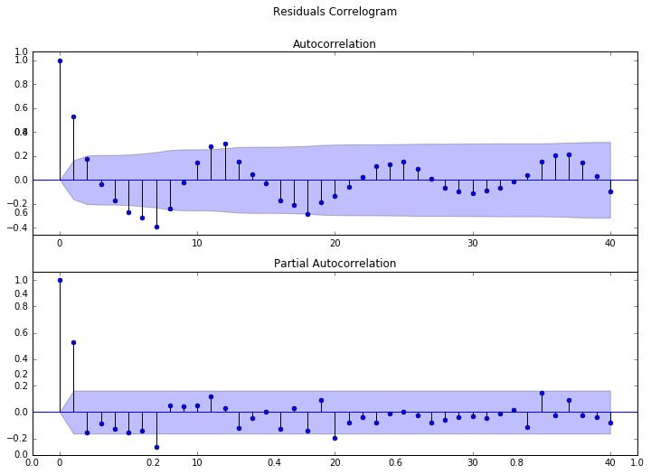

```python
fig = plt.figure(figsize=(12,8))
plt.title('Residuals Correlogram', y=1.08)
ax1 = fig.add_subplot(211)
fig = sm.graphics.tsa.plot_acf(res.resid, lags=40, ax=ax1)
ax2 = fig.add_subplot(212)
fig = sm.graphics.tsa.plot_pacf(res.resid, lags=40, ax=ax2)
```

Looking at the correlogram it looks like we still have memory since de ACF decays exponentially and the PACF truncates at either 2nd or 3nd lag, suggesting an AR(1) or AR(2). Also the shape of the ACF suggests some kind of seasonality.

# ARIMA Model

First we will try to model de memory structure of the series

```python
mod = tsa.arima_model.ARMA(inflation['Ipca'].astype(float),order=[1,0], exog=factors[[0,1,2,3]].astype(float))

res = mod.fit()
print(res.summary())
```

```
                              ARMA Model Results
==============================================================================
Dep. Variable:                   Ipca   No. Observations:                  145
Model:                     ARMA(1, 0)   Log Likelihood                 704.123
Method:                       css-mle   S.D. of innovations              0.002
Date:                Mon, 27 Jun 2016   AIC                          -1394.246
Time:                        00:25:44   BIC                          -1373.409
Sample:                    01-01-2004   HQIC                         -1385.780
                         - 01-01-2016
==============================================================================
                 coef    std err          z      P>|z|      [95.0% Conf. Int.]
------------------------------------------------------------------------------
const          0.0050      0.000     13.933      0.000         0.004     0.006
0              0.0002   6.55e-05      2.566      0.011      3.97e-05     0.000
1              0.0012      0.000      2.929      0.004         0.000     0.002
2              0.0011      0.000      2.343      0.021         0.000     0.002
3              0.0003      0.001      0.565      0.573        -0.001     0.001
ar.L1.Ipca     0.5650      0.071      7.986      0.000         0.426     0.704
                                    Roots
=============================================================================
                 Real           Imaginary           Modulus         Frequency
-----------------------------------------------------------------------------
AR.1            1.7700           +0.0000j            1.7700            0.0000
-----------------------------------------------------------------------------
```

We can see that the first lag is highly significant, but now the 4th factor (indexed by 3) isn't sinificatn anymore.

```python
mod = tsa.arima_model.ARMA(inflation['Ipca'].astype(float),order=[1,0], exog=factors[[0,1,2]].astype(float))

res = mod.fit()
print(res.summary())
```

```
                              ARMA Model Results
==============================================================================
Dep. Variable:                   Ipca   No. Observations:                  145
Model:                     ARMA(1, 0)   Log Likelihood                 703.965
Method:                       css-mle   S.D. of innovations              0.002
Date:                Mon, 27 Jun 2016   AIC                          -1395.929
Time:                        00:25:44   BIC                          -1378.069
Sample:                    01-01-2004   HQIC                         -1388.672
                         - 01-01-2016
==============================================================================
                 coef    std err          z      P>|z|      [95.0% Conf. Int.]
------------------------------------------------------------------------------
const          0.0050      0.000     13.684      0.000         0.004     0.006
0              0.0002   6.66e-05      2.536      0.012      3.84e-05     0.000
1              0.0012      0.000      2.979      0.003         0.000     0.002
2              0.0012      0.000      2.715      0.007         0.000     0.002
ar.L1.Ipca     0.5725      0.069      8.303      0.000         0.437     0.708
                                    Roots
=============================================================================
                 Real           Imaginary           Modulus         Frequency
-----------------------------------------------------------------------------
AR.1            1.7468           +0.0000j            1.7468            0.0000
-----------------------------------------------------------------------------
```

Our new model has an AIC of -1395.929 and a BIC of -1378.069 as opposed to 1346 and 1332, respectively , from the last model.

```python
trace1 = go.Scatter(
    x = list(inflation['Ipca'].index),
    y = inflation['Ipca'],
    name = 'Actual'
)

trace2 = go.Scatter(
    x = list(inflation['Ipca'].index),
    y = res.fittedvalues,
    name = 'Fitted'
)

layout = go.Layout(
    title='IPCA Nowcasting - ARIMA Model',
    )

data = [trace1, trace2]

fig = go.Figure(data=data, layout=layout)
# Plot and embed in ipython notebook!
iplot(fig)
```

[interactive chart not shown]

```python
trace2 = go.Scatter(
    x = list(inflation['Ipca'].index),
    y = res.resid,
    name = 'Residuals'
)

layout = go.Layout(
    title='IPCA Nowcasting - ARIMA Model - Residuals',
    )

data = [trace2]

fig = go.Figure(data=data, layout=layout)
# Plot and embed in ipython notebook!
iplot(fig)
```

[interactive chart not shown]

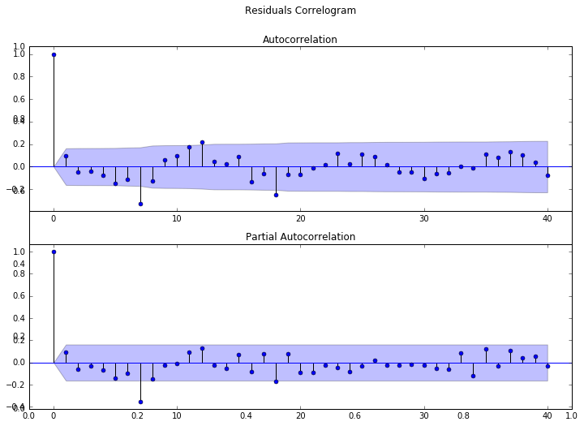

```python
fig = plt.figure(figsize=(12,8))
plt.title('Residuals Correlogram', y=1.08)
ax1 = fig.add_subplot(211)
fig = sm.graphics.tsa.plot_acf(res.resid, lags=40, ax=ax1)
ax2 = fig.add_subplot(212)
fig = sm.graphics.tsa.plot_pacf(res.resid, lags=40, ax=ax2)
```

The shape of both the ACF and the PACF indicate some form of seasonality since they both seem to oscilate.

# Seasonal ARIMA

Due to the smooth oscillatory shape of the ACF we do not believe that an ARIMA model with gapped lags would solve the problem. We will try to model it with dummy variables for months. Since we need only 11 dummy variables we will choose march as the "base" level.

We believe month seasonality to be plausible since holidays are usually on the same month of the year, ex: Christmas. And several other reasons like harvesting season and etc.

```python
factors['January'] = 0
factors['February'] = 0
factors['April'] = 0
factors['May'] = 0
factors['June'] = 0
factors['July'] = 0
factors['August'] = 0
factors['September'] = 0
factors['October'] = 0
factors['November'] = 0
factors['December'] = 0
```

```python
factors.loc[factors.index.month == 1,'January'] = 1
factors.loc[factors.index.month == 2,'February'] = 1
factors.loc[factors.index.month == 4,'April'] = 1
factors.loc[factors.index.month == 5,'May'] = 1
factors.loc[factors.index.month == 6,'June'] = 1
factors.loc[factors.index.month == 7,'July'] = 1
factors.loc[factors.index.month == 8,'August'] = 1
factors.loc[factors.index.month == 9,'September'] = 1
factors.loc[factors.index.month == 10,'October'] = 1
factors.loc[factors.index.month == 11,'November'] = 1
factors.loc[factors.index.month == 12,'December'] = 1
factors.head()
```

| Date | 0 | 1 | 2 | 3 | 4 | Const | January | February | April | May | June | July | August | September | October | November | December |
| --- | --- | --- | --- | --- | --- | --- | --- | --- | --- | --- | --- | --- | --- | --- | --- | --- | --- |
| 2004-01-01 | -8.141221 | 1.930160 | 1.939037 | 0.232444 | 0.158040 | 1 | 1 | 0 | 0 | 0 | 0 | 0 | 0 | 0 | 0 | 0 | 0 |
| 2004-02-01 | -7.738660 | 1.536987 | 1.196552 | -0.527399 | -0.630851 | 1 | 0 | 1 | 0 | 0 | 0 | 0 | 0 | 0 | 0 | 0 | 0 |
| 2004-03-01 | -7.452846 | 0.951614 | 0.381476 | -1.446818 | 0.099085 | 1 | 0 | 0 | 0 | 0 | 0 | 0 | 0 | 0 | 0 | 0 | 0 |
| 2004-04-01 | -7.277189 | 1.048334 | 1.290536 | -0.257251 | -0.673827 | 1 | 0 | 0 | 1 | 0 | 0 | 0 | 0 | 0 | 0 | 0 | 0 |
| 2004-05-01 | -6.858319 | 1.116246 | 1.577769 | -0.901072 | -0.646554 | 1 | 0 | 0 | 0 | 1 | 0 | 0 | 0 | 0 | 0 | 0 | 0 |

```python
data = factors[[0,
                1,
                2,
                'January',
                'February',
                'April',
                'May',
                'June',
                'July',
                'August',
                'September',
                'October',
                'November',
                'December',
               ]]

mod = tsa.arima_model.ARMA(inflation['Ipca'].astype(float),order=[1,0], exog=data.astype(float))

res = mod.fit(maxiter=100)
print(res.summary())
```

```
                              ARMA Model Results
==============================================================================
Dep. Variable:                   Ipca   No. Observations:                  145
Model:                     ARMA(1, 0)   Log Likelihood                 721.580
Method:                       css-mle   S.D. of innovations              0.002
Date:                Mon, 27 Jun 2016   AIC                          -1409.160
Time:                        00:25:47   BIC                          -1358.555
Sample:                    01-01-2004   HQIC                         -1388.597
                         - 01-01-2016
==============================================================================
                 coef    std err          z      P>|z|      [95.0% Conf. Int.]
------------------------------------------------------------------------------
const          0.0060      0.001     10.903      0.000         0.005     0.007
0              0.0002   4.47e-05      3.506      0.001      6.92e-05     0.000
1              0.0013      0.000      3.651      0.000         0.001     0.002
2              0.0009      0.000      1.956      0.053     -1.63e-06     0.002
January        0.0006      0.001      0.845      0.400        -0.001     0.002
February       0.0005      0.001      0.778      0.438        -0.001     0.002
April         -0.0004      0.001     -0.726      0.469        -0.002     0.001
May           -0.0014      0.001     -2.065      0.041        -0.003 -7.23e-05
June          -0.0029      0.001     -3.999      0.000        -0.004    -0.002
July          -0.0030      0.001     -4.042      0.000        -0.004    -0.002
August        -0.0032      0.001     -4.241      0.000        -0.005    -0.002
September     -0.0022      0.001     -2.895      0.004        -0.004    -0.001
October       -0.0008      0.001     -1.120      0.265        -0.002     0.001
November      -0.0001      0.001     -0.138      0.891        -0.002     0.001
December       0.0004      0.001      0.488      0.627        -0.001     0.002
ar.L1.Ipca     0.4248      0.077      5.540      0.000         0.274     0.575
                                    Roots
=============================================================================
                 Real           Imaginary           Modulus         Frequency
-----------------------------------------------------------------------------
AR.1            2.3543           +0.0000j            2.3543            0.0000
-----------------------------------------------------------------------------
```

At a 5% confidence level wecan say that the months January, February, April, October, November and December are no different from march. We will try a model without those month's dummy variables.

```python
data = factors[[0,
                1,
                2,
                'May',
                'June',
                'July',
                'August',
                'September',
               ]]

mod = tsa.arima_model.ARMA(inflation['Ipca'].astype(float),order=[1,0], exog=data.astype(float))

res = mod.fit(maxiter=100)
print(res.summary())
```

```
                              ARMA Model Results
==============================================================================
Dep. Variable:                   Ipca   No. Observations:                  145
Model:                     ARMA(1, 0)   Log Likelihood                 718.934
Method:                       css-mle   S.D. of innovations              0.002
Date:                Mon, 27 Jun 2016   AIC                          -1415.868
Time:                        00:25:47   BIC                          -1383.124
Sample:                    01-01-2004   HQIC                         -1402.563
                         - 01-01-2016
==============================================================================
                 coef    std err          z      P>|z|      [95.0% Conf. Int.]
------------------------------------------------------------------------------
const          0.0059      0.000     19.988      0.000         0.005     0.006
0              0.0002   4.59e-05      3.442      0.001       6.8e-05     0.000
1              0.0013      0.000      4.111      0.000         0.001     0.002
2              0.0010      0.000      2.727      0.007         0.000     0.002
May           -0.0012      0.001     -2.240      0.027        -0.002    -0.000
June          -0.0028      0.001     -4.741      0.000        -0.004    -0.002
July          -0.0028      0.001     -4.666      0.000        -0.004    -0.002
August        -0.0029      0.001     -4.899      0.000        -0.004    -0.002
September     -0.0018      0.001     -3.344      0.001        -0.003    -0.001
ar.L1.Ipca     0.4317      0.077      5.587      0.000         0.280     0.583
                                    Roots
=============================================================================
                 Real           Imaginary           Modulus         Frequency
-----------------------------------------------------------------------------
AR.1            2.3164           +0.0000j            2.3164            0.0000
-----------------------------------------------------------------------------
```

Our new model's AIC and BIC are -1415.868 and -1383.124 respectively, which are lower than our previous values of -1395.929 and -1378.069

```python
trace1 = go.Scatter(
    x = list(inflation['Ipca'].index),
    y = inflation['Ipca'],
    name = 'Actual'
)

trace2 = go.Scatter(
    x = list(inflation['Ipca'].index),
    y = res.fittedvalues,
    name = 'Fitted'
)

layout = go.Layout(
    title='IPCA Nowcasting - ARIMA Seasonal Model',
    )

data = [trace1, trace2]

fig = go.Figure(data=data, layout=layout)
# Plot and embed in ipython notebook!
iplot(fig)
```

[interactive chart not shown]

```python
trace2 = go.Scatter(
    x = list(inflation['Ipca'].index),
    y = res.resid,
    name = 'Residuals'
)

layout = go.Layout(
    title='IPCA Nowcasting - ARIMA Seasonal Model - Residuals',
    )

data = [trace2]

fig = go.Figure(data=data, layout=layout)
# Plot and embed in ipython notebook!
iplot(fig)
```

[interactive chart not shown]

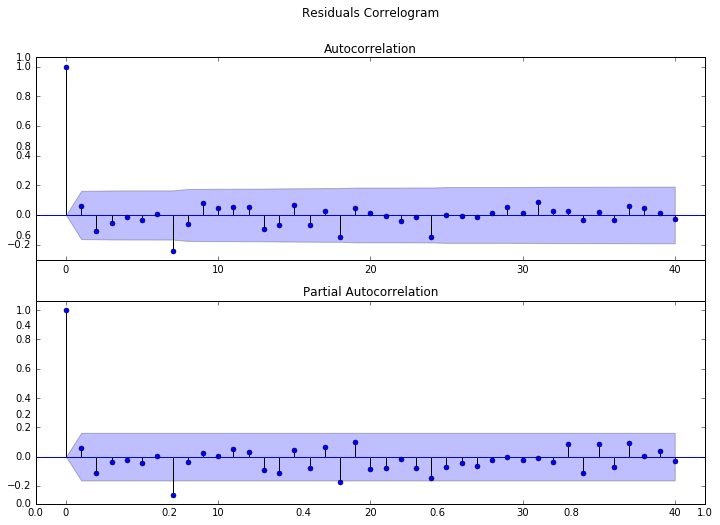

```python
fig = plt.figure(figsize=(12,8))
plt.title('Residuals Correlogram', y=1.08)
ax1 = fig.add_subplot(211)
fig = sm.graphics.tsa.plot_acf(res.resid, lags=40, ax=ax1)
ax2 = fig.add_subplot(212)
fig = sm.graphics.tsa.plot_pacf(res.resid, lags=40, ax=ax2)
```

# Conclusion

Even though we believe we found our final model it doesn't change the fact the the factors coefficients as the dummy variables coefficient are extremely low, speacially compared to the AR coefficient.

It is hard to believe that this model would beat the naive AR(1) consistently.

We can analyze both residuals regressed against a constant, to check their estimated means and standard deviations.

```python
modelResiduals = sm.OLS(res.resid, factors['Const'].astype(float))
resmodelResiduals = modelResiduals.fit()
print(resmodelResiduals.summary())
```

```
                            OLS Regression Results
==============================================================================
Dep. Variable:                      y   R-squared:                       0.000
Model:                            OLS   Adj. R-squared:                  0.000
Method:                 Least Squares   F-statistic:                       inf
Date:                Mon, 27 Jun 2016   Prob (F-statistic):                nan
Time:                        00:25:48   Log-Likelihood:                 718.96
No. Observations:                 145   AIC:                            -1436.
Df Residuals:                     144   BIC:                            -1433.
Df Model:                           0
Covariance Type:            nonrobust
==============================================================================
                 coef    std err          t      P>|t|      [95.0% Conf. Int.]
------------------------------------------------------------------------------
Const       4.672e-06      0.000      0.033      0.974        -0.000     0.000
==============================================================================
Omnibus:                        0.899   Durbin-Watson:                   1.857
Prob(Omnibus):                  0.638   Jarque-Bera (JB):                0.923
Skew:                          -0.043   Prob(JB):                        0.630
Kurtosis:                       2.618   Cond. No.                         1.00
==============================================================================

Warnings:
[1] Standard Errors assume that the covariance matrix of the errors is correctly specified.
```

```python
naiveAr = tsa.arima_model.ARMA(inflation['Ipca'].astype(float),order=[1,0])

resnaiveAr = naiveAr.fit(maxiter=100)
print(resnaiveAr.summary())

naiveArResiduals = sm.OLS(resnaiveAr.resid, factors['Const'].astype(float))
resAr = naiveArResiduals.fit()
print(resAr.summary())
```

```
                              ARMA Model Results
==============================================================================
Dep. Variable:                   Ipca   No. Observations:                  145
Model:                     ARMA(1, 0)   Log Likelihood                 696.152
Method:                       css-mle   S.D. of innovations              0.002
Date:                Mon, 27 Jun 2016   AIC                          -1386.304
Time:                        00:25:48   BIC                          -1377.374
Sample:                    01-01-2004   HQIC                         -1382.676
                         - 01-01-2016
==============================================================================
                 coef    std err          z      P>|z|      [95.0% Conf. Int.]
------------------------------------------------------------------------------
const          0.0051      0.001      9.784      0.000         0.004     0.006
ar.L1.Ipca     0.6867      0.063     10.865      0.000         0.563     0.811
                                    Roots
=============================================================================
                 Real           Imaginary           Modulus         Frequency
-----------------------------------------------------------------------------
AR.1            1.4563           +0.0000j            1.4563            0.0000
-----------------------------------------------------------------------------
                            OLS Regression Results
==============================================================================
Dep. Variable:                      y   R-squared:                       0.000
Model:                            OLS   Adj. R-squared:                  0.000
Method:                 Least Squares   F-statistic:                       inf
Date:                Mon, 27 Jun 2016   Prob (F-statistic):                nan
Time:                        00:25:48   Log-Likelihood:                 696.10
No. Observations:                 145   AIC:                            -1390.
Df Residuals:                     144   BIC:                            -1387.
Df Model:                           0
Covariance Type:            nonrobust
==============================================================================
                 coef    std err          t      P>|t|      [95.0% Conf. Int.]
------------------------------------------------------------------------------
Const      -1.189e-05      0.000     -0.072      0.943        -0.000     0.000
==============================================================================
Omnibus:                        0.210   Durbin-Watson:                   1.806
Prob(Omnibus):                  0.900   Jarque-Bera (JB):                0.379
Skew:                          -0.010   Prob(JB):                        0.827
Kurtosis:                       2.750   Cond. No.                         1.00
==============================================================================

Warnings:
[1] Standard Errors assume that the covariance matrix of the errors is correctly specified.
```

```python
trace1 = go.Scatter(
    x = list(inflation['Ipca'].index),
    y = inflation['Ipca'],
    name = 'Actual'
)

trace2 = go.Scatter(
    x = list(inflation['Ipca'].index),
    y = res.fittedvalues,
    name = 'Fitted Model'
)

trace3 = go.Scatter(
    x = list(inflation['Ipca'].index),
    y = resnaiveAr.fittedvalues,
    name = 'Fitted Naive AR(1)'
)

layout = go.Layout(
    title='IPCA Nowcasting - THE FINAL BATTLE',
    )

data = [trace1, trace2, trace3]

fig = go.Figure(data=data, layout=layout)
# Plot and embed in ipython notebook!
iplot(fig)
```

[interactive chart not shown]

Our final model's AIC and BIC values are -1415.868 and -1383.124 against -1386 -1377 from the naive AR(1).

# Future Research

## Searches for Inflação

We speculate that searches for inflação will be lagged in relation to the actual inflation, just for fun.

## Partial Squares and Kalman Filter

We used the two step process using PCA. Both Partial Squares and Kalman Filter methodologies could be employed to improve estimations and "variables selection"

## Back to Rates

We could convert our forecasts back to rate of changes to compare with the actual IPCA series

## Better ways of comparing to the naive AR

We didn't focus on comparing the models, we could use more sofisticated methodologies to do so.